```python
import warnings
warnings.simplefilter(action = 'ignore', category = FutureWarning)

import numpy as np
import pandas as pd
import matplotlib.pyplot as plt
import seaborn as sns
sns.set()

import dslab

%matplotlib inline
%load_ext autoreload
%autoreload 2
```

```
C:\Users\kguo1\Anaconda3\envs\term121x_env\python.exe
{'numpy': '1.20.1', 'pandas': '1.1.3', 'seaborn': '0.11.0', 'sklearn': '0.23.2', 'matplotlib': '3.3.1'}
```

# I. Frame the Problem

## I.1 What is the business objective?

To try and predict the cost of a house in Ames, Iwoa, given several different variables, some of which may not come intuitively as an influence in the decision to purchase a property.

The predivtive variables range fromt he typical variables (such as the original construction date, lot size etc.) to more non-standard variables (such as the type of alley access or the slope of the property).

This allows us to gain a deeper understanding on all the underlying factors that have an influence no the customers decision to purcahse a property, as well as to reduce time and costs of predcting potential property sales prices.

## I.2 How will your solution be used?

As the exact purpose of the solution has not been formalised, we've made the assumption that our model output will be fed into a separate Machine Learning model, with the final purpose to be determining whether a property of land is worth purchasing.

## I.3 What are the current solutions/workarounds?

Currently, the sales price is being predicted manually by experts, and is a timely and costly process.

While they consider a wide range of potential variables in their estimation process, it is assumed that the list of variables is not as exhaustive as what our Machine Learning program, and so their predicted value likely not as accurate, or their process not as robust as our algorithm.

## I.4 How should you frame this problem?

The problem is a case of supervised learning(as the training set provides labels for the model to learn from), and should be a regression task (due to property cost is a numeric value). The model should be fitted through batch learning techniques.

## I.5 How should performanace be measured?

Performance should be measured using Root mean-squared error (RMSE).

## I.6 Is the performanace measure aligned with the business objective?

RMSE performance measure allows the predicted value to have the same units (both in dollars) as the original business obnjective of predicting property costs in Ames, Iowa.

## I.7 What would be the minimum performance needed to reach the business objective?

The RMSE value should be better than $\$70,000$ USD.

## I.8 What are comparable problems? Can you reuse experience or tools?

Problem is quite similar t othe California District House Pricing Project (https://github.com/ageron/handson-ml/blob/master/02_end_to_end_machine_learning_project.ipynb) and so code used from this project (mainly exploratory analysis step) can be refurnished for this task.

Python library 'scikit-learn' will be useful in helping to create the models, 'seaborn' for visualising our data points, and 'numpy' and 'pandas' for helping in transforming and storing the data in a useable format.

## I.9 Is human expertise available?

Ask Andreas.

## I.10 How would you solve the problem manually?

Go through the data provided, and through consultation with industry experts, gain an understanding of the interactions and influence each of the variables have with one another and with the Sales Price. From here we're able to gain insight in the experts decisions rules, and hopefully be able to determine the most significant variables.

## I.11 List the assumptions you (or others) have made so far

This process is completed as part of submitting the assignment.

## I.12 Verify assumptions if possible

This process is completed as part of the marking process of the assignment.

# II. Get the Data

Due to the nature of the assignment, the preparation for all the data has already been provided for us prior to importing. As such, the majority of the steps aren't required for this project.

## II.2 Find the Document where you can get that data

The data can be found here: https://www.kaggle.com/c/engsci-762-term1213

## II.5 Get Access Authorisation

The data is stored in a public repository, so no access authorisations is required

## II.7 Get the Data

```python
house_train = pd.read_csv('train.csv',
                index_col = 0,
                na_values = 'NaN',
                keep_default_na = False)

house_test = pd.read_csv('test.csv',
                  index_col = 0,
                  na_values = 'NaN',
                  keep_default_na = False)
```

## II.9 Summary of all numeric attributes

```python
house_train.describe()
```

|  | MSSubClass | LotArea | OverallQual | OverallCond | YearBuilt | YearRemodAdd | BsmtFinSF1 | BsmtFinSF2 | BsmtUnfSF | TotalBsmtSF | ... | WoodDeckSF | OpenPorchSF | EnclosedPorch | 3SsnPorch | ScreenPorch | PoolArea | MiscVal | MoSold | YrSold | SalePrice |
| --- | --- | --- | --- | --- | --- | --- | --- | --- | --- | --- | --- | --- | --- | --- | --- | --- | --- | --- | --- | --- | --- |
| count | 1460.000000 | 1460.000000 | 1460.000000 | 1460.000000 | 1460.000000 | 1460.000000 | 1460.000000 | 1460.000000 | 1460.000000 | 1460.000000 | ... | 1460.000000 | 1460.000000 | 1460.000000 | 1460.000000 | 1460.000000 | 1460.000000 | 1460.000000 | 1460.000000 | 1460.000000 | 1460.000000 |
| mean | 56.897260 | 10516.828082 | 6.099315 | 5.575342 | 1971.267808 | 1984.865753 | 443.639726 | 46.549315 | 567.240411 | 1057.429452 | ... | 94.244521 | 46.660274 | 21.954110 | 3.409589 | 15.060959 | 2.758904 | 43.489041 | 6.321918 | 2007.815753 | 180923.935616 |
| std | 42.300571 | 9981.264932 | 1.382997 | 1.112799 | 30.202904 | 20.645407 | 456.098091 | 161.319273 | 441.866955 | 438.705324 | ... | 125.338794 | 66.256028 | 61.119149 | 29.317331 | 55.757415 | 40.177307 | 496.123024 | 2.703626 | 1.328095 | 79440.814521 |
| min | 20.000000 | 1300.000000 | 1.000000 | 1.000000 | 1872.000000 | 1950.000000 | 0.000000 | 0.000000 | 0.000000 | 0.000000 | ... | 0.000000 | 0.000000 | 0.000000 | 0.000000 | 0.000000 | 0.000000 | 0.000000 | 1.000000 | 2006.000000 | 34900.000000 |
| 25% | 20.000000 | 7553.500000 | 5.000000 | 5.000000 | 1954.000000 | 1967.000000 | 0.000000 | 0.000000 | 223.000000 | 795.750000 | ... | 0.000000 | 0.000000 | 0.000000 | 0.000000 | 0.000000 | 0.000000 | 0.000000 | 5.000000 | 2007.000000 | 129975.000000 |
| 50% | 50.000000 | 9478.500000 | 6.000000 | 5.000000 | 1973.000000 | 1994.000000 | 383.500000 | 0.000000 | 477.500000 | 991.500000 | ... | 0.000000 | 25.000000 | 0.000000 | 0.000000 | 0.000000 | 0.000000 | 0.000000 | 6.000000 | 2008.000000 | 163000.000000 |
| 75% | 70.000000 | 11601.500000 | 7.000000 | 6.000000 | 2000.000000 | 2004.000000 | 712.250000 | 0.000000 | 808.000000 | 1298.250000 | ... | 168.000000 | 68.000000 | 0.000000 | 0.000000 | 0.000000 | 0.000000 | 0.000000 | 8.000000 | 2009.000000 | 214000.000000 |
| max | 190.000000 | 215245.000000 | 10.000000 | 9.000000 | 2010.000000 | 2010.000000 | 5644.000000 | 1474.000000 | 2336.000000 | 6110.000000 | ... | 857.000000 | 547.000000 | 552.000000 | 508.000000 | 480.000000 | 738.000000 | 15500.000000 | 12.000000 | 2010.000000 | 755000.000000 |

8 rows × 34 columns

# III. Explore the data

## III.1 Create a Jupyter Notebook

This was completed as the header for the notebook in order to allow the data to be imported.

## III.2 Study each attribute and its characteristics

```python
house_train.info()
```

```
<class 'pandas.core.frame.DataFrame'>
Int64Index: 1460 entries, 1474 to 1489
Data columns (total 80 columns):
 #   Column         Non-Null Count  Dtype
---  ------         --------------  -----
 0   MSSubClass     1460 non-null   int64
 1   MSZoning       1460 non-null   object
 2   LotFrontage    1460 non-null   object
 3   LotArea        1460 non-null   int64
 4   Street         1460 non-null   object
 5   Alley          1460 non-null   object
 6   LotShape       1460 non-null   object
 7   LandContour    1460 non-null   object
 8   Utilities      1460 non-null   object
 9   LotConfig      1460 non-null   object
```

[output cut: 72 more lines]

From the data description file we can see that there are 79 explanatory variables, 46 of which are categorical and 33 which are numeric.

There are 1460 total entires in the training data set, and there don't appear to be any missing values for any of the explanatory variables

### Exploring the Categorical Variables

To streamline the distribution plotting for categorical variables, can introduce a function for plotting.

```python
def plot_CatVar(variable, title, xlab):
    _ = house_train[variable].value_counts().plot(kind = 'bar')
    _ = plt.title(title)
    _ = plt.xlabel(xlab)
    _ = plt.ylabel("Observations")
```

#### MSSubClass

Identifies the type of dwelling involved in the sale

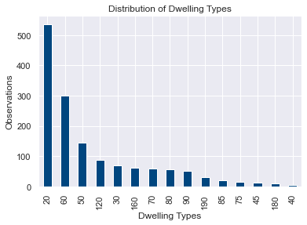

```python
plot_CatVar('MSSubClass', 'Distribution of Dwelling Types', 'Dwelling Types')
```

#### MSZoning

Identifies the general zoning classification of the sale

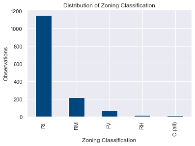

```python
plot_CatVar('MSZoning', 'Distribution of Zoning Classification', 'Zoning Classification')
```

#### Street

Type fo road access to property

```
Pave    1454
Grvl       6
Name: Street, dtype: int64
```

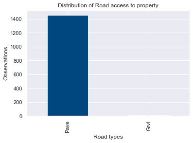

```python
plot_CatVar('Street', 'Distribution of Road access to property', 'Road types')
house_train.Street.value_counts()
```

#### Alley

Type of alley access to property

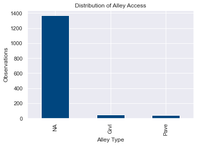

```python
plot_CatVar('Alley', 'Distribution of Alley Access', 'Alley Type')
```

#### LotShape

General shape of property

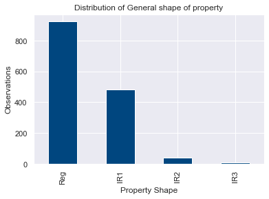

```python
plot_CatVar('LotShape', 'Distribution of General shape of property', 'Property Shape')
```

#### LandContour

Flatness of the property

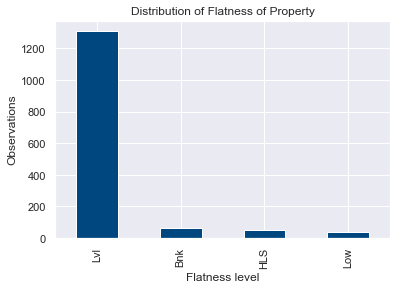

```python
plot_CatVar('LandContour', 'Distribution of Flatness of Property', 'Flatness level')
```

#### Utilities

Type of utilities available

```
AllPub    1459
NoSeWa       1
Name: Utilities, dtype: int64
```

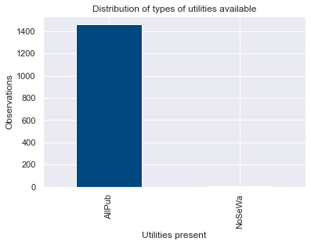

```python
plot_CatVar('Utilities', 'Distribution of types of utilities available', 'Utilities present')
house_train.Utilities.value_counts()
```

#### LotConfig

Lot configuration

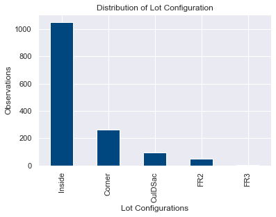

```python
plot_CatVar('LotConfig', 'Distribution of Lot Configuration', 'Lot Configurations')
```

#### LandSlope

Slope of property

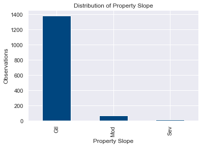

```python
plot_CatVar('LandSlope', 'Distribution of Property Slope', 'Property Slope')
```

#### Neighborhood

Physical locations within Ames city limits

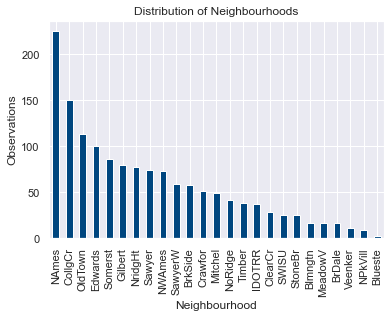

```python
plot_CatVar('Neighborhood', 'Distribution of Neighbourhoods', 'Neighbourhood')
```

#### Condition1

Proximity to various conditions

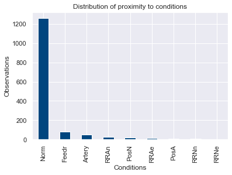

```python
plot_CatVar('Condition1', 'Distribution of proximity to conditions', 'Conditions')
```

#### Condition2

Proximity to various conditions (if more than one is present)

```
Norm      1445
Feedr        6
PosN         2
RRNn         2
Artery       2
RRAn         1
RRAe         1
PosA         1
Name: Condition2, dtype: int64
```

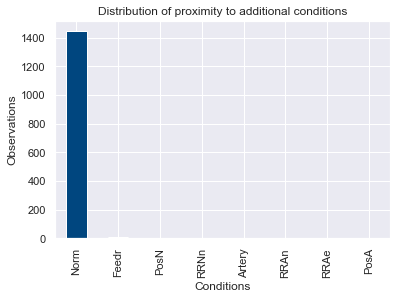

```python
plot_CatVar('Condition2', 'Distribution of proximity to additional conditions', 'Conditions')
house_train.Condition2.value_counts()
```

#### BldgType

Type of dwelling

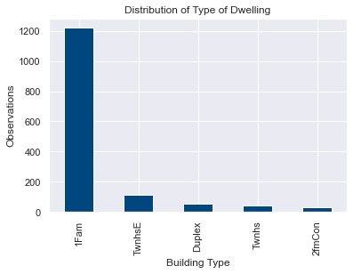

```python
plot_CatVar('BldgType', 'Distribution of Type of Dwelling', 'Building Type')
```

#### HouseStyle

Style of dwelling

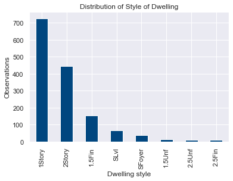

```python
plot_CatVar('HouseStyle', 'Distribution of Style of Dwelling', 'Dwelling style')
```

#### OverallQual

Rates the overall material and finish of the house

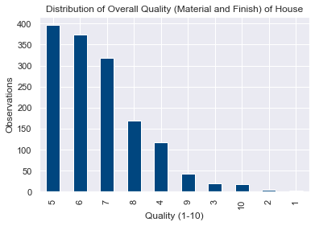

```python
plot_CatVar('OverallQual', 'Distribution of Overall Quality (Material and Finish) of House', 'Quality (1-10)')
```

#### OverallCond

Rates the overall condition of the house

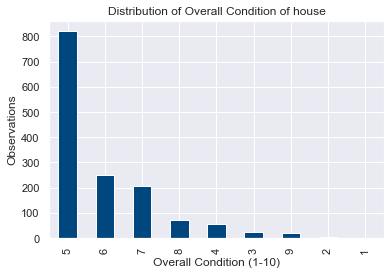

```python
plot_CatVar('OverallCond', 'Distribution of Overall Condition of house', 'Overall Condition (1-10)')
```

#### RoofStyle

Type of roof

```
Gable      1141
Hip         286
Flat         13
Gambrel      11
Mansard       7
Shed          2
Name: RoofStyle, dtype: int64
```

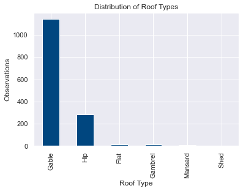

```python
plot_CatVar('RoofStyle', 'Distribution of Roof Types', 'Roof Type')
house_train.RoofStyle.value_counts()
```

#### RoofMatl

Roof material

```
CompShg    1434
Tar&Grv      11
WdShngl       6
WdShake       5
Metal         1
Roll          1
ClyTile       1
Membran       1
Name: RoofMatl, dtype: int64
```

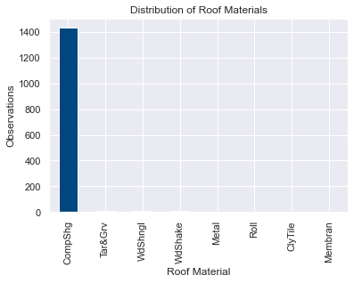

```python
plot_CatVar('RoofMatl', 'Distribution of Roof Materials', 'Roof Material')
house_train.RoofMatl.value_counts()
```

#### Exterior1st

Exterior covering on house

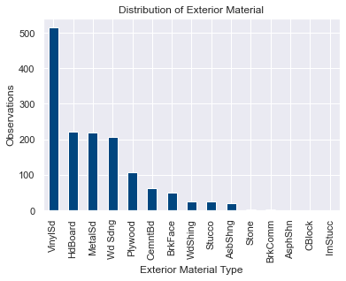

```python
plot_CatVar('Exterior1st', 'Distribution of Exterior Material', 'Exterior Material Type')
```

#### Exterior2nd

Exterior covering on house (if more than one material)

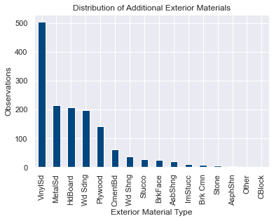

```python
plot_CatVar('Exterior2nd', 'Distribution of Additional Exterior Materials', 'Exterior Material Type')
```

#### MasVnrType

Masonry veneer type

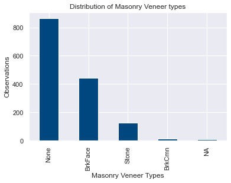

```python
plot_CatVar('MasVnrType', 'Distribution of Masonry Veneer types', 'Masonry Veneer Types')
```

#### ExterQual

Evaluates the quality of the material on the exterior

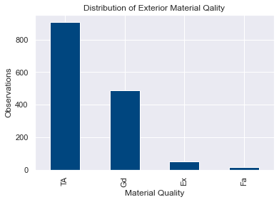

```python
plot_CatVar('ExterQual', 'Distribution of Exterior Material Qality', 'Material Quality')
```

#### ExterCond

Evaluates the present condition of the material on the exterior

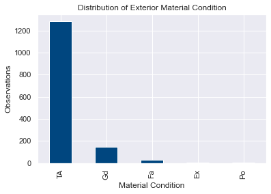

```python
plot_CatVar('ExterCond', 'Distribution of Exterior Material Condition', 'Material Condition')
```

#### Foundation

Type of foundation

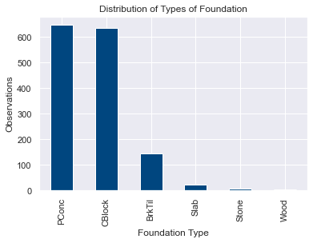

```python
plot_CatVar('Foundation', 'Distribution of Types of Foundation', 'Foundation Type')
```

#### BsmtQual

Evaluates the height of the basement

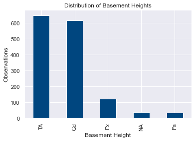

```python
plot_CatVar('BsmtQual', 'Distribution of Basement Heights', 'Basement Height')
```

#### BsmtCond

Evaluates the general condition of the basement

```
TA    1311
Gd      65
Fa      45
NA      37
Po       2
Name: BsmtCond, dtype: int64
```

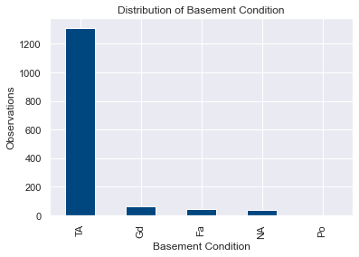

```python
plot_CatVar('BsmtCond', 'Distribution of Basement Condition', 'Basement Condition')
house_train.BsmtCond.value_counts()
```

#### BsmtExposure

Refers to walkout or garden level walls

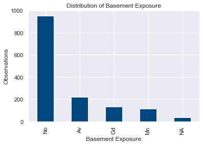

```python
plot_CatVar('BsmtExposure', 'Distribution of Basement Exposure', 'Basement Exposure')
```